# Analyzing primary ad buys in Connecticut

Andrew Ba Tran

April 17, 2016

#### This is an exploratory analysis of ad buys in Connecticut via presidential candidates leading up to the primary election

This analysis accompanies the Trend CT story

- [Bernie Sanders, Hillary Clinton campaigns increasing ad buys before CT primaries](http://trendct.org/?p=11872)

This analysis is based off data aggregated by the Sunlight Foundation’s [PoliticalAdSleuth.com](http://politicaladsleuth.com).

- [`ad_extractor.R`](https://github.com/trendct/data/blob/master/2016/04/ad-buys-ct/ad_extractor.R) pulled the dataframe from politicaladsleuth.com and PDFs from the FCC
- [`parser_totals.R`](https://github.com/trendct/data/blob/master/2016/04/ad-buys-ct/parser_totals.R) extracted data from the converted PDFs and pulled it into a dataframe
- Data is only as recent as 4/15/16. Primary election day is 4/26/16, so expect more filings between then.
- Check out [the repo](https://github.com/trendct/data/tree/master/2016/04/ad-buys-ct) with all scripts and data

Let’s load up the packages we’ll need

```r
library(RCurl)
library(dplyr)
library(lubridate)
library(stringr)
library(ggplot2)
library(tidyr)
library(DT)
```

#### Bringing in the data from [`ad_extractor.R`](https://github.com/trendct/data/blob/master/2016/04/ad-buys-ct/ad_extractor.R) and [`parser_totals.R`](https://github.com/trendct/data/blob/master/2016/04/ad-buys-ct/parser_totals.R) and joining them.

```r
url <- "http://trendct.github.io/data/2016/04/ad-buys-ct/data/ad_buys.csv"
the_csv <- getURL(url)
totals <- read.csv(textConnection(the_csv), stringsAsFactors=FALSE)

# totals <- read.csv("data/ad_buys.csv", stringsAsFactors=FALSE)
totals$gross.amount <- gsub("\\$", "", totals$gross.amount)
totals$gross.amount <- gsub(",", "", totals$gross.amount)
totals$gross.amount <- as.numeric(totals$gross.amount)

totals$net.amount <- gsub("\\$", "", totals$net.amount)
totals$net.amount <- gsub(",", "", totals$net.amount)
totals$net.amount <- as.numeric(totals$net.amount)

totals$agency.commission <- totals$gross.amount - totals$net.amount

# making the dates recongized by R

totals$time.period.start <- mdy(totals$time.period.start)
totals$time.period.end <- mdy(totals$time.period.end)

totals$sheet <- gsub("spreadsheets/", "", totals$sheet)
totals$sheet <- gsub(".xlsx", "", totals$sheet)

# joining the data with the original dataframe from ad_extractor.R
# this will add more details like station and advertiser

url <- "http://trendct.github.io/data/2016/04/ad-buys-ct/data/ads_dataframe.csv"
the_csv <- getURL(url)
presi_table <- read.csv(textConnection(the_csv), stringsAsFactors=FALSE)

# presi_table <- read.csv("data/ads_dataframe.csv", stringsAsFactors=FALSE)
totals <- left_join(totals, presi_table, by="sheet")

# create a new column identifying the candidate based on what group bought the ad
totals$candidate <- ""

for (i in 1:nrow(totals)) {
  info <- str_to_upper(totals$Advertiser.File.Info[i])
  if (grepl("BERNIE", info)) {
    totals$candidate[i] <- "Bernie Sanders"
  } else if (grepl("HILLARY", info)) {
    totals$candidate[i] <- "Hillary Clinton"
  } else {
    totals$candidate[i] <- "Other"

  }
}

# cleaning up the column names to eliminate spaces
colnames(totals) <- c("row", "time.period.start", "time.period.end", "spots", "gross.amount", "agency.commission", "net.amount", "sheet", "row2", "tv.station", "market", "date", "type", "status", "spots2", "cost2", "advertiser", "link", "doc", "candidate")
totals <- totals[c("candidate",  "tv.station", "market", "date", "time.period.start", "time.period.end", "spots", "gross.amount", "agency.commission", "net.amount", "sheet", "advertiser", "link", "doc")]
```

#### Cleaning up the data

- Determining the group purchasing the ads
- Discarding out-of-date contracts
- Discarding invoices

```r
# create a new column identifying the group
totals$group <- ""

for (i in 1:nrow(totals)) {
  info <- str_to_upper(totals$advertiser[i])
  if (grepl("HILLARY 2016", info)) {
    totals$group[i] <- "Hillary 2016"
  } else if (grepl("BERNIE SANDERS FOR PRESIDENT", info)) {
    totals$group[i] <- "Bernie Sanders for President"
  } else if (grepl("HILLARY CLINTON", info)) {
    totals$group[i] <- "Hillary Clinton"
  } else if (grepl("BERNIE SANDERS", info)) {
    totals$group[i] <- "Bernie Sanders"
  }  else if (grepl("BERNIE 2016", info)) {
    totals$group[i] <- "Bernie 2016"
  } else if (grepl("HILLARY FOR AMERICA", info)) {
    totals$group[i] <- "Hillary for America"
  }
}


# Picking out the most-recent contracts, discarding the invoices with no pricing data
check <- totals %>%
  group_by(tv.station, time.period.start, time.period.end, candidate) %>%
  arrange(-spots)

check2 <- totals
check2$mega <- paste(check2$tv.station, check2$time.period.start,check2$time.period.end,check2$candidate)

check3 <- check2 %>%
  group_by(mega) %>%
  top_n(n = 1, wt=spots)

# Making sure there are no duplicate rows
check3 <- unique(check3)


# Now check to see if there are any overlapping time periods
check3$interval <- interval(check3$time.period.start, check3$time.period.end)

check3$overlaps <- ""
rows <- nrow(check3)-1
for (i in 1:rows) {
    if ((check3$tv.station[i]==check3$tv.station[i+1]) && (check3$group[i]==check3$group[i+1])) {
      if (int_overlaps(check3$interval[i], check3$interval[i+1])) {
      check3$overlaps[i] <- "yes"
      check3$overlaps[i+1] <- "yes" }
      else {
        check3$overlaps[i] <- "no"
      }
    } else {
      check3$overlaps[i] <- "no"
    }
}

# Alright, just a handful of overlapping contact periods
# It looks like there was one Hillary contract that was revised to expand the time period and increase ad buys
# Will take out the older contract

check3 <- subset(check3, sheet!="04_11_16WFSB14603982219469_38")
```

## Some preliminary analysys

```r
# How much did each candidate spend on ad buys in CT?
tapply(check3$gross.amount, check3$candidate, sum)
```

```
##  Bernie Sanders Hillary Clinton
##          722190          171720
```

```r
# How many ads did they buy each?
tapply(check3$spots, check3$candidate, sum)
```

```
##  Bernie Sanders Hillary Clinton
##            1864             784
```

```r
## How many ads by station?
tapply(check3$spots, check3$tv.station, sum)
```

```
## WCCT-TV    WCTX    WFSB WTIC-TV    WTNH    WVIT
##     405     415     431     335     551     511
```

```r
# How many by ad period start date?
tapply(check3$spots, check3$time.period.start, sum)
```

```
## 2016-03-28 2016-04-25
##       2446        202
```

```r
# How many ads did each group purchase?
tapply(check3$spots, check3$group, sum)
```

```
##                  Bernie 2016               Bernie Sanders
##                          936                          532
## Bernie Sanders for President                 Hillary 2016
##                          396                          389
##              Hillary Clinton          Hillary for America
##                          208                          187
```

```r
# How much was spent by each group?
tapply(check3$gross.amount, check3$group, sum)
```

```
##                  Bernie 2016               Bernie Sanders
##                       344060                        79645
## Bernie Sanders for President                 Hillary 2016
##                       298485                        60550
##              Hillary Clinton          Hillary for America
##                        26830                        84340
```

```r
# How much was spent total by date of FCC filing?
tapply(check3$gross.amount, check3$date, sum)
```

```
## 04/08/16 04/11/16 04/12/16 04/13/16 04/14/16 04/15/16
##    23405   183810    94195   296785   109805   185910
```

## Visualizing the analysis

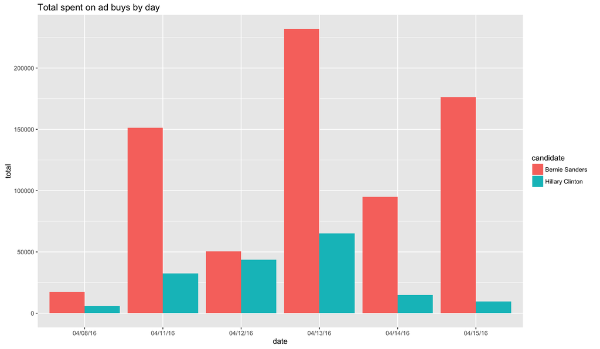

```r
## Money spent by FCC filing date
sum_date <- check3 %>%
  group_by(date, candidate, tv.station) %>%
  summarise(total=sum(gross.amount))

sum_date_only <- check3 %>%
  group_by(date, candidate) %>%
  summarise(total=sum(gross.amount))

ggplot(data=sum_date_only, aes(x=date, y=total, fill=candidate)) +
  geom_bar(stat="identity", position=position_dodge()) + ggtitle("Total spent on ad buys by day")
```

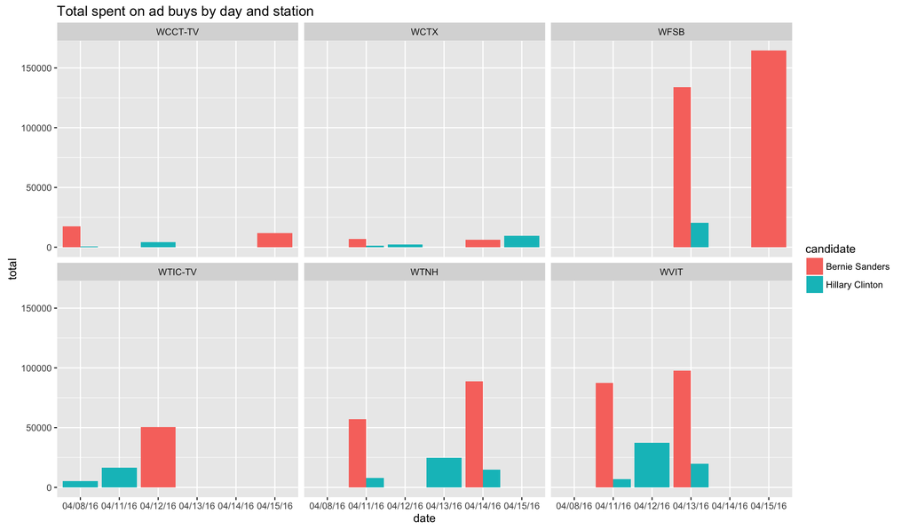

```r
ggplot(data=sum_date, aes(x=date, y=total, fill=candidate)) +
  geom_bar(stat="identity", position=position_dodge())+ facet_wrap(~tv.station) +
  ggtitle("Total spent on ad buys by day and station")
```

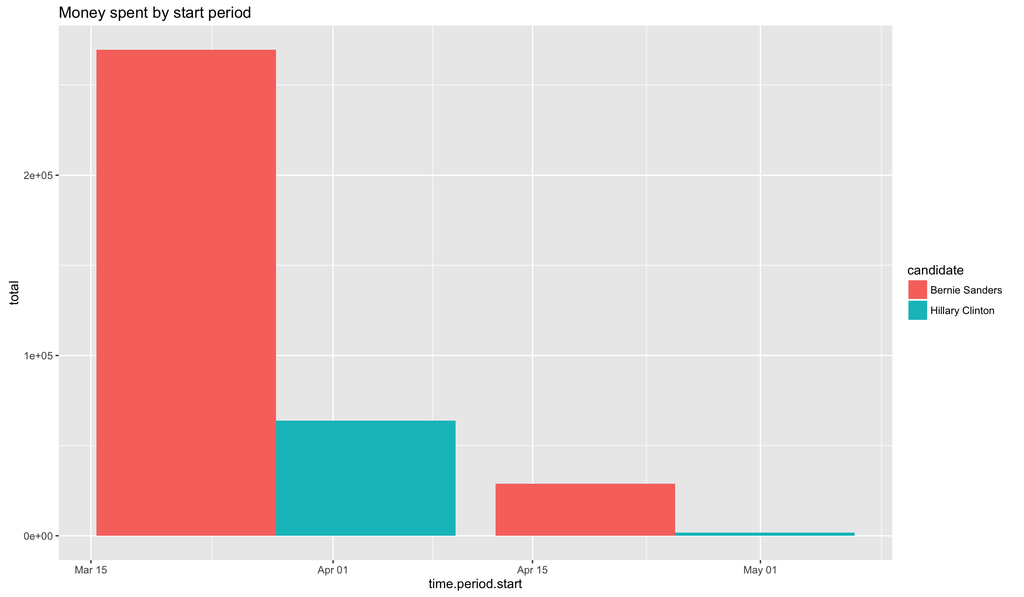

```r
## Money spent by start period

sum_period_start <- check3 %>%
  group_by(time.period.start, candidate, tv.station) %>%
  summarise(total=sum(gross.amount))

ggplot(data=sum_period_start, aes(x=time.period.start, y=total, fill=candidate)) +
  geom_bar(stat="identity", position=position_dodge()) +
  ggtitle("Money spent by start period")
```

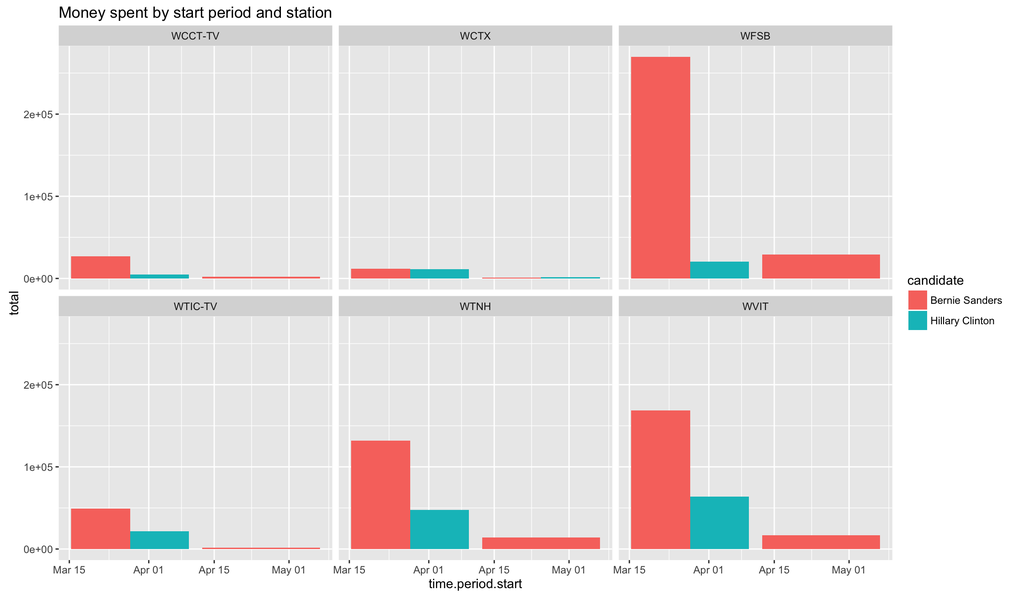

```r
ggplot(data=sum_period_start, aes(x=time.period.start, y=total, fill=candidate)) +
  geom_bar(stat="identity", position=position_dodge())+ facet_wrap(~tv.station) +
 ggtitle("Money spent by start period and station")
```

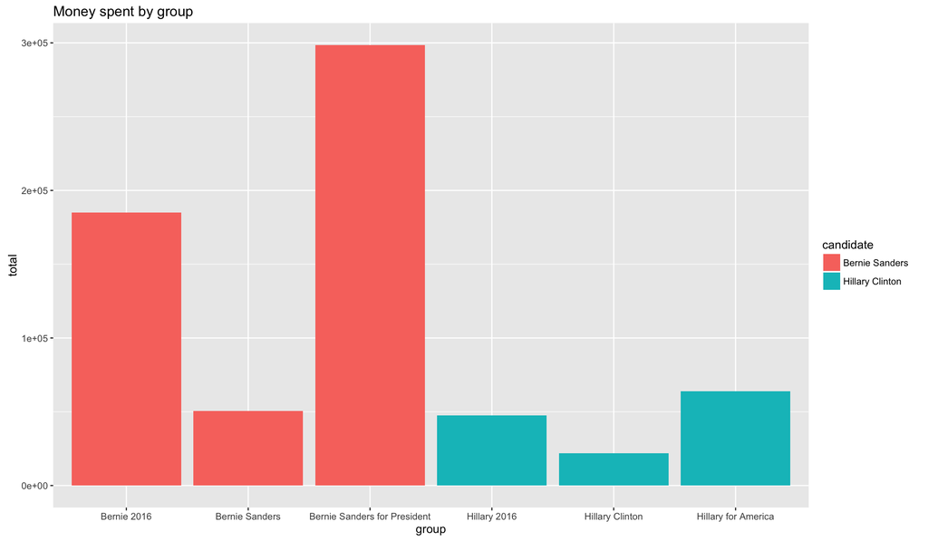

```r
## Money spent by group

sum_group <- check3 %>%
  group_by(group, candidate, tv.station) %>%
  summarise(total=sum(gross.amount))

ggplot(data=sum_group, aes(x=group, y=total, fill=candidate)) +
  geom_bar(stat="identity", position=position_dodge()) +
 ggtitle("Money spent by group")
```

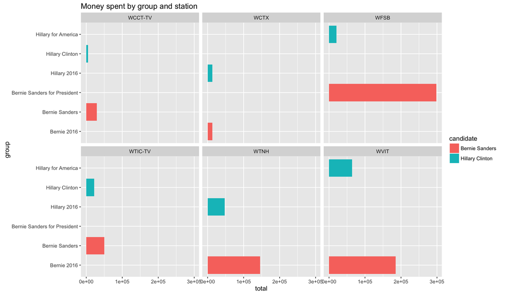

```r
ggplot(data=sum_group, aes(x=group, y=total, fill=candidate)) +
  geom_bar(stat="identity", position=position_dodge())+ facet_wrap(~tv.station) + coord_flip() +
 ggtitle("Money spent by group and station")
```

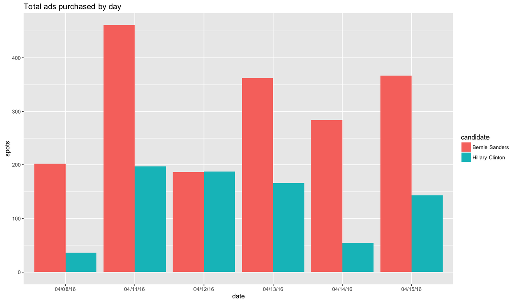

```r
## Spots by FCC filing date

spots_date <- check3 %>%
  group_by(date, candidate, tv.station) %>%
  summarise(spots=sum(spots))

spots_date2 <- check3 %>%
  group_by(date, candidate) %>%
  summarise(spots=sum(spots))

ggplot(data=spots_date2, aes(x=date, y=spots, fill=candidate)) +
  geom_bar(stat="identity", position=position_dodge()) +
  ggtitle("Total ads purchased by day")
```

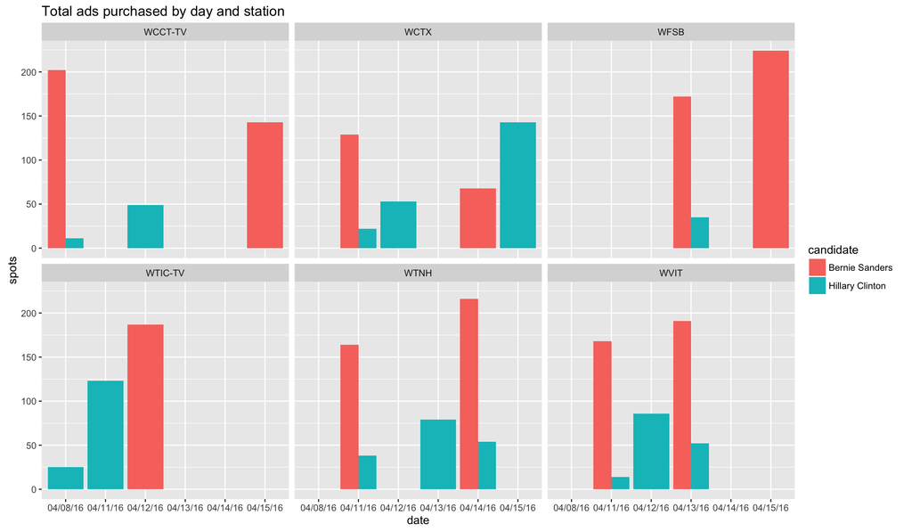

```r
ggplot(data=spots_date, aes(x=date, y=spots, fill=candidate)) +
  geom_bar(stat="identity", position=position_dodge())+ facet_wrap(~tv.station) +
  ggtitle("Total ads purchased by day and station")
```

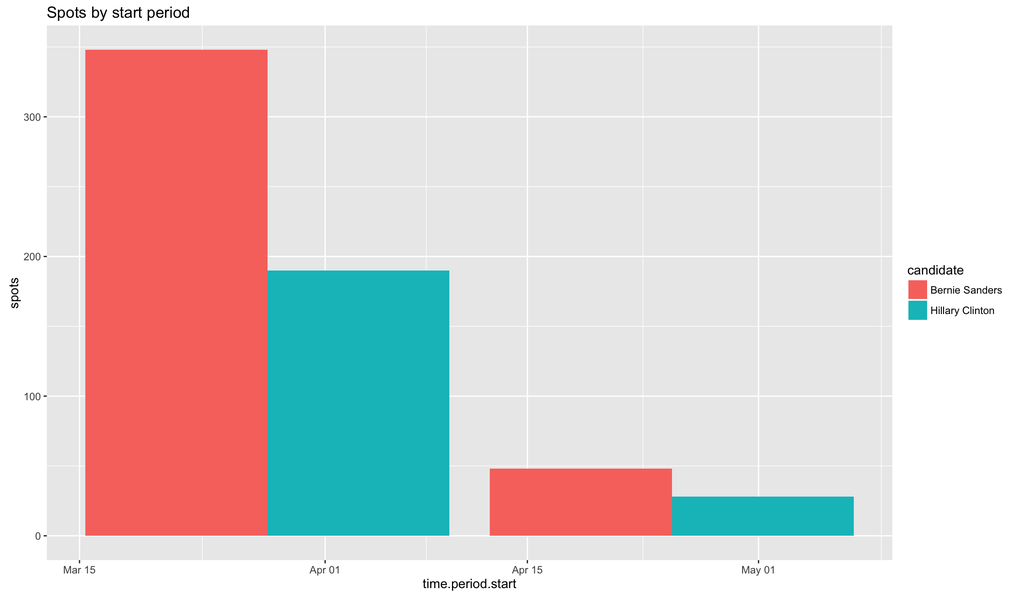

```r
## spots by start period
spot_period_start <- check3 %>%
  group_by(time.period.start, candidate, tv.station) %>%
  summarise(spots=sum(spots))

ggplot(data=spot_period_start, aes(x=time.period.start, y=spots, fill=candidate)) +
  geom_bar(stat="identity", position=position_dodge()) +
  ggtitle("Spots by start period")
```

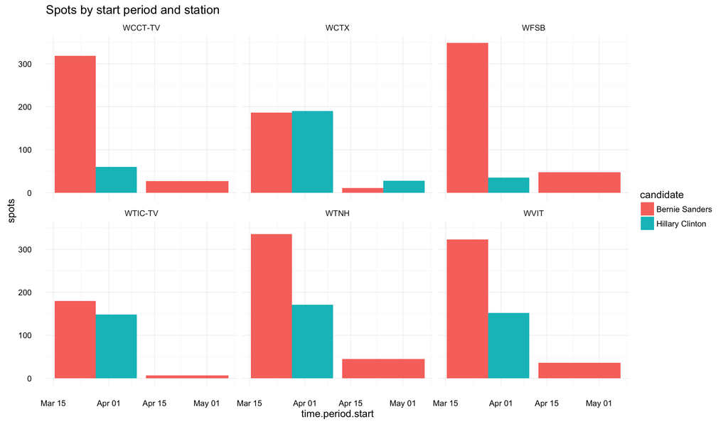

```r
ggplot(data=spot_period_start, aes(x=time.period.start, y=spots, fill=candidate)) +
  geom_bar(stat="identity", position=position_dodge()) + facet_wrap(~tv.station) + theme_minimal() +
  ggtitle("Spots by start period and station")
```

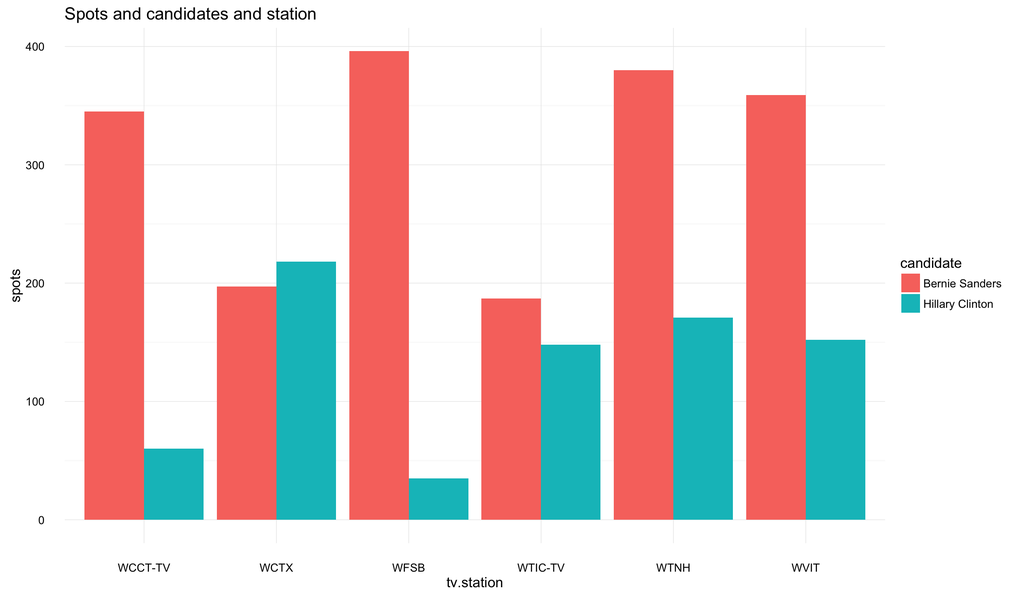

```r
# Spots and Candidates and Station

scs <- check3 %>%
  group_by(candidate, tv.station) %>%
  summarise(spots=sum(spots))

ggplot(data=scs, aes(x=tv.station, y=spots, fill=candidate)) +
  geom_bar(stat="identity", position=position_dodge()) + theme_minimal() +
  ggtitle("Spots and candidates and station")
```

```r
## for datatables

for_dt <- check3
for_dt <- for_dt[c("candidate", "group", "tv.station", "date", "spots", "net.amount", "agency.commission", "gross.amount", "time.period.start", "time.period.end")]
colnames(for_dt) <- c("Candidate", "Group", "Station", "Date", "Spots", "Net amount", "Commission", "Gross amount", "Ad start", "Ad end")
for_dt <- data.frame(for_dt)
datatable(for_dt)
```

|  | Candidate | Group | Station | Date | Spots | Net.amount | Commission | Gross.amount | Ad.start | Ad.end |
| --- | --- | --- | --- | --- | --- | --- | --- | --- | --- | --- |
| 1 | Hillary Clinton | Hillary 2016 | WCTX | 04/15/16 | 115 | 6613 | 1167 | 7780 | 2016-03-28T00:00:00Z | 2016-04-24T00:00:00Z |
| 2 | Hillary Clinton | Hillary 2016 | WCTX | 04/15/16 | 28 | 1525.75 | 269.25 | 1795 | 2016-04-25T00:00:00Z | 2016-04-30T00:00:00Z |
| 3 | Bernie Sanders | Bernie Sanders for President | WFSB | 04/15/16 | 176 | 115230.25 | 20334.75 | 135565 | 2016-03-28T00:00:00Z | 2016-04-24T00:00:00Z |
| 4 | Bernie Sanders | Bernie Sanders for President | WFSB | 04/15/16 | 48 | 24590.5 | 4339.5 | 28930 | 2016-04-25T00:00:00Z | 2016-04-26T00:00:00Z |
| 5 | Hillary Clinton | Hillary Clinton | WCCT-TV | 04/08/16 | 11 | 569.5 | 100.5 | 670 | 2016-03-28T00:00:00Z | 2016-04-11T00:00:00Z |
| 6 | Bernie Sanders | Bernie Sanders | WCCT-TV | 04/08/16 | 202 | 14768.75 | 2606.25 | 17375 | 2016-03-28T00:00:00Z | 2016-04-16T00:00:00Z |
| 7 | Hillary Clinton | Hillary Clinton | WTIC-TV | 04/08/16 | 25 | 4556 | 804 | 5360 | 2016-03-28T00:00:00Z | 2016-04-11T00:00:00Z |
| 8 | Bernie Sanders | Bernie 2016 | WCTX | 04/11/16 | 129 | 5954.25 | 1050.75 | 7005 | 2016-03-28T00:00:00Z | 2016-04-16T00:00:00Z |
| 9 | Hillary Clinton | Hillary 2016 | WCTX | 04/11/16 | 22 | 1071 | 189 | 1260 | 2016-03-28T00:00:00Z | 2016-04-11T00:00:00Z |
| 10 | Hillary Clinton | Hillary Clinton | WTIC-TV | 04/11/16 | 123 | 13935.75 | 2459.25 | 16395 | 2016-03-28T00:00:00Z | 2016-04-18T00:00:00Z |

[output cut: 24 more lines]

# Conclusions

Read the story in TrendCT.org:

**[Bernie Sanders, Hillary Clinton campaigns increasing ad buys before CT primaries](http://trendct.org/?p=11872)**